# Part I - (Prosper Loan Data Exploration)

## by (Olaniyan Daniel Olusegun)

## Introduction

> This document explores a dataset containing borrower's APR and attributes for approximately 113937 loans.

## Preliminary Wrangling

> This project is divided into two major sections

> In the first, an exploratory data analysis of a dataset was conducted. Python programming and data visualization libraries was used to explore the dataset's variables and understand the data's structure, pattern's and relationships.

> This analysis is structured as the Univariate, Bi-variate and Multivariate relationship was investigated.

> In the second, findings from our exploration was taken and then conveyed through exploratory analysis. A slide deck was created to communicate findings easily.

### Project Aim

> I would be investigating the factors that affect a loan's outcome status

## Data Gathering

### **1- Importing Libraries**

```python
# import all packages and set plots to be embedded inline
import numpy as np
import pandas as pd
import matplotlib.pyplot as plt
import seaborn as sb


%matplotlib inline
```

### **2- Getting Data**

```python
# load in the dataset into a pandas dataframe, print statistics
loan_data = pd.read_csv('prosperLoanData.csv')
```

```python
loan_data.head()
```

|  | ListingKey | ListingNumber | ListingCreationDate | CreditGrade | Term | LoanStatus | ClosedDate | BorrowerAPR | BorrowerRate | LenderYield | ... | LP_ServiceFees | LP_CollectionFees | LP_GrossPrincipalLoss | LP_NetPrincipalLoss | LP_NonPrincipalRecoverypayments | PercentFunded | Recommendations | InvestmentFromFriendsCount | InvestmentFromFriendsAmount | Investors |
| --- | --- | --- | --- | --- | --- | --- | --- | --- | --- | --- | --- | --- | --- | --- | --- | --- | --- | --- | --- | --- | --- |
| 0 | 1021339766868145413AB3B | 193129 | 2007-08-26 19:09:29.263000000 | C | 36 | Completed | 2009-08-14 00:00:00 | 0.16516 | 0.1580 | 0.1380 | ... | -133.18 | 0.0 | 0.0 | 0.0 | 0.0 | 1.0 | 0 | 0 | 0.0 | 258 |
| 1 | 10273602499503308B223C1 | 1209647 | 2014-02-27 08:28:07.900000000 | NaN | 36 | Current | NaN | 0.12016 | 0.0920 | 0.0820 | ... | 0.00 | 0.0 | 0.0 | 0.0 | 0.0 | 1.0 | 0 | 0 | 0.0 | 1 |
| 2 | 0EE9337825851032864889A | 81716 | 2007-01-05 15:00:47.090000000 | HR | 36 | Completed | 2009-12-17 00:00:00 | 0.28269 | 0.2750 | 0.2400 | ... | -24.20 | 0.0 | 0.0 | 0.0 | 0.0 | 1.0 | 0 | 0 | 0.0 | 41 |
| 3 | 0EF5356002482715299901A | 658116 | 2012-10-22 11:02:35.010000000 | NaN | 36 | Current | NaN | 0.12528 | 0.0974 | 0.0874 | ... | -108.01 | 0.0 | 0.0 | 0.0 | 0.0 | 1.0 | 0 | 0 | 0.0 | 158 |
| 4 | 0F023589499656230C5E3E2 | 909464 | 2013-09-14 18:38:39.097000000 | NaN | 36 | Current | NaN | 0.24614 | 0.2085 | 0.1985 | ... | -60.27 | 0.0 | 0.0 | 0.0 | 0.0 | 1.0 | 0 | 0 | 0.0 | 20 |

5 rows × 81 columns

```python
for i in loan_data:
    print(f'{loan_data[i]} -- {loan_data[i].unique()}')
#     print(f'{i}')
```

[output not shown]

[output cut: 1702 more lines]

[output not shown]

```python
loan_data.info()
```

```
<class 'pandas.core.frame.DataFrame'>
RangeIndex: 113937 entries, 0 to 113936
Data columns (total 81 columns):
 #   Column                               Non-Null Count   Dtype
---  ------                               --------------   -----
 0   ListingKey                           113937 non-null  object
 1   ListingNumber                        113937 non-null  int64
 2   ListingCreationDate                  113937 non-null  object
 3   CreditGrade                          28953 non-null   object
 4   Term                                 113937 non-null  int64
 5   LoanStatus                           113937 non-null  object
 6   ClosedDate                           55089 non-null   object
 7   BorrowerAPR                          113912 non-null  float64
 8   BorrowerRate                         113937 non-null  float64
 9   LenderYield                          113937 non-null  float64
```

[output cut: 73 more lines]

```python
loan_data.dtypes
```

```
ListingKey                      object
ListingNumber                    int64
ListingCreationDate             object
CreditGrade                     object
Term                             int64
                                ...
PercentFunded                  float64
Recommendations                  int64
InvestmentFromFriendsCount       int64
InvestmentFromFriendsAmount    float64
Investors                        int64
Length: 81, dtype: object
```

### What is/are the main feature(s) of interest in your dataset?

> I'm most interested in figuring out what features are best for predicting the Borrower's Annual Percentage Rate (borrower_apr) in the dataset.

### What features in the dataset do you think will help support your investigation into your feature(s) of interest?

> Term  
> BorrowerAPR  
> BorrowerRate LenderYield EstimatedEffectiveYield  
> EstimatedLoss EstimatedReturn  
> ProsperRating (numeric)  
> ProsperScore  
> IsBorrowerHomeowner  
> CreditScoreRangeLower CreditScoreRangeUpper CurrentCreditLines  
> OpenCreditLines  
> OpenRevolvingAccounts

##### 2-1-Selecting Data Columns to visualize

```python
cols_needed = ["ListingKey", "Term", "LoanStatus", "BorrowerAPR", "BorrowerRate",
               "LenderYield", "EstimatedEffectiveYield", "EstimatedLoss",
               "EstimatedReturn", "ProsperRating (Alpha)", "ProsperScore",
               "IsBorrowerHomeowner", "CurrentlyInGroup", "CreditScoreRangeLower",
               "CreditScoreRangeUpper"]

loan_data_new = loan_data.loc[:,cols_needed].copy()
```

```python
loan_data_new
```

|  | ListingKey | Term | LoanStatus | BorrowerAPR | BorrowerRate | LenderYield | EstimatedEffectiveYield | EstimatedLoss | EstimatedReturn | ProsperRating (Alpha) | ProsperScore | IsBorrowerHomeowner | CurrentlyInGroup | CreditScoreRangeLower | CreditScoreRangeUpper |
| --- | --- | --- | --- | --- | --- | --- | --- | --- | --- | --- | --- | --- | --- | --- | --- |
| 0 | 1021339766868145413AB3B | 36 | Completed | 0.16516 | 0.1580 | 0.1380 | NaN | NaN | NaN | NaN | NaN | True | True | 640.0 | 659.0 |
| 1 | 10273602499503308B223C1 | 36 | Current | 0.12016 | 0.0920 | 0.0820 | 0.07960 | 0.0249 | 0.05470 | A | 7.0 | False | False | 680.0 | 699.0 |
| 2 | 0EE9337825851032864889A | 36 | Completed | 0.28269 | 0.2750 | 0.2400 | NaN | NaN | NaN | NaN | NaN | False | True | 480.0 | 499.0 |
| 3 | 0EF5356002482715299901A | 36 | Current | 0.12528 | 0.0974 | 0.0874 | 0.08490 | 0.0249 | 0.06000 | A | 9.0 | True | False | 800.0 | 819.0 |
| 4 | 0F023589499656230C5E3E2 | 36 | Current | 0.24614 | 0.2085 | 0.1985 | 0.18316 | 0.0925 | 0.09066 | D | 4.0 | True | False | 680.0 | 699.0 |
| ... | ... | ... | ... | ... | ... | ... | ... | ... | ... | ... | ... | ... | ... | ... | ... |
| 113932 | E6D9357655724827169606C | 36 | Current | 0.22354 | 0.1864 | 0.1764 | 0.16490 | 0.0699 | 0.09500 | C | 5.0 | True | False | 700.0 | 719.0 |
| 113933 | E6DB353036033497292EE43 | 36 | FinalPaymentInProgress | 0.13220 | 0.1110 | 0.1010 | 0.10070 | 0.0200 | 0.08070 | A | 8.0 | True | False | 700.0 | 719.0 |
| 113934 | E6E13596170052029692BB1 | 60 | Current | 0.23984 | 0.2150 | 0.2050 | 0.18828 | 0.1025 | 0.08578 | D | 3.0 | True | False | 700.0 | 719.0 |
| 113935 | E6EB3531504622671970D9E | 60 | Completed | 0.28408 | 0.2605 | 0.2505 | 0.24450 | 0.0850 | 0.15950 | C | 5.0 | True | False | 680.0 | 699.0 |
| 113936 | E6ED3600409833199F711B7 | 36 | Current | 0.13189 | 0.1039 | 0.0939 | 0.09071 | 0.0299 | 0.06081 | A | 7.0 | False | False | 680.0 | 699.0 |

113937 rows × 15 columns

##### 2-2-Renaming columns

```python
loan_data_new.columns=loan_data_new.columns.str.lower()
```

```python
loan_data_new.columns=['listing_key',
                   'term',
                   'loan_status',
                   'borrower_apr',
                   'borrower_rate',
                    'lender_yield',
                   'estimated_effective_yield',
                   'estimated_loss',
                   'estimated_return',
                   'prosper_rating_alpha',
                   'prosper_score',
                   'is_borrower_home_owner',
                   'currently_in_group',
                   'credit_score_range_lower',
                   'credit_score_range_upper',
                  ]
```

##### 2-3-Checking null values

```python
loan_data_new.isnull().sum()
```

```
listing_key                      0
term                             0
loan_status                      0
borrower_apr                    25
borrower_rate                    0
lender_yield                     0
estimated_effective_yield    29084
estimated_loss               29084
estimated_return             29084
prosper_rating_alpha         29084
prosper_score                29084
is_borrower_home_owner           0
currently_in_group               0
credit_score_range_lower       591
credit_score_range_upper       591
dtype: int64
```

```python
loan_data_new.dropna(axis=0, inplace=True)
```

```python
loan_data_new.isnull().sum()
```

```
listing_key                  0
term                         0
loan_status                  0
borrower_apr                 0
borrower_rate                0
lender_yield                 0
estimated_effective_yield    0
estimated_loss               0
estimated_return             0
prosper_rating_alpha         0
prosper_score                0
is_borrower_home_owner       0
currently_in_group           0
credit_score_range_lower     0
credit_score_range_upper     0
dtype: int64
```

##### 2-4-Checking duplicates

```python
sum(loan_data_new['listing_key'].duplicated())
```

```
871
```

```python
loan_data = loan_data_new.drop_duplicates(subset=['listing_key'], keep='last')
```

```python
sum(loan_data_new['listing_key'].duplicated())
```

```
871
```

## Exploratory Data Analysis

```python
# display information about the cleaned dataset
loan_data_new.info()
```

```
<class 'pandas.core.frame.DataFrame'>
Int64Index: 84853 entries, 1 to 113936
Data columns (total 15 columns):
 #   Column                     Non-Null Count  Dtype
---  ------                     --------------  -----
 0   listing_key                84853 non-null  object
 1   term                       84853 non-null  int64
 2   loan_status                84853 non-null  object
 3   borrower_apr               84853 non-null  float64
 4   borrower_rate              84853 non-null  float64
 5   lender_yield               84853 non-null  float64
 6   estimated_effective_yield  84853 non-null  float64
 7   estimated_loss             84853 non-null  float64
 8   estimated_return           84853 non-null  float64
 9   prosper_rating_alpha       84853 non-null  object
 10  prosper_score              84853 non-null  float64
 11  is_borrower_home_owner     84853 non-null  bool
 12  currently_in_group         84853 non-null  bool
 13  credit_score_range_lower   84853 non-null  float64
 14  credit_score_range_upper   84853 non-null  float64
dtypes: bool(2), float64(9), int64(1), object(3)
memory usage: 9.2+ MB
```

```python
# print out the first 6 rows of data
loan_data_new.head()
```

|  | listing_key | term | loan_status | borrower_apr | borrower_rate | lender_yield | estimated_effective_yield | estimated_loss | estimated_return | prosper_rating_alpha | prosper_score | is_borrower_home_owner | currently_in_group | credit_score_range_lower | credit_score_range_upper |
| --- | --- | --- | --- | --- | --- | --- | --- | --- | --- | --- | --- | --- | --- | --- | --- |
| 1 | 10273602499503308B223C1 | 36 | Current | 0.12016 | 0.0920 | 0.0820 | 0.07960 | 0.0249 | 0.05470 | A | 7.0 | False | False | 680.0 | 699.0 |
| 3 | 0EF5356002482715299901A | 36 | Current | 0.12528 | 0.0974 | 0.0874 | 0.08490 | 0.0249 | 0.06000 | A | 9.0 | True | False | 800.0 | 819.0 |
| 4 | 0F023589499656230C5E3E2 | 36 | Current | 0.24614 | 0.2085 | 0.1985 | 0.18316 | 0.0925 | 0.09066 | D | 4.0 | True | False | 680.0 | 699.0 |
| 5 | 0F05359734824199381F61D | 60 | Current | 0.15425 | 0.1314 | 0.1214 | 0.11567 | 0.0449 | 0.07077 | B | 10.0 | True | False | 740.0 | 759.0 |
| 6 | 0F0A3576754255009D63151 | 36 | Current | 0.31032 | 0.2712 | 0.2612 | 0.23820 | 0.1275 | 0.11070 | E | 2.0 | False | False | 680.0 | 699.0 |

```python
# show the shape of the data
loan_data_new.shape
```

```
(84853, 15)
```

```python
# descriptive statistics for numeric variables
loan_data_new.describe()
```

|  | term | borrower_apr | borrower_rate | lender_yield | estimated_effective_yield | estimated_loss | estimated_return | prosper_score | credit_score_range_lower | credit_score_range_upper |
| --- | --- | --- | --- | --- | --- | --- | --- | --- | --- | --- |
| count | 84853.000000 | 84853.000000 | 84853.000000 | 84853.000000 | 84853.000000 | 84853.000000 | 84853.000000 | 84853.000000 | 84853.000000 | 84853.000000 |
| mean | 42.486135 | 0.226658 | 0.196022 | 0.186017 | 0.168661 | 0.080306 | 0.096068 | 5.950067 | 699.390240 | 718.390240 |
| std | 11.640346 | 0.079916 | 0.074631 | 0.074631 | 0.068467 | 0.046764 | 0.030403 | 2.376501 | 47.095937 | 47.095937 |
| min | 12.000000 | 0.045830 | 0.040000 | 0.030000 | -0.182700 | 0.004900 | -0.182700 | 1.000000 | 600.000000 | 619.000000 |
| 25% | 36.000000 | 0.163280 | 0.135900 | 0.125900 | 0.115670 | 0.042400 | 0.074080 | 4.000000 | 660.000000 | 679.000000 |
| 50% | 36.000000 | 0.219450 | 0.187500 | 0.177500 | 0.161500 | 0.072400 | 0.091700 | 6.000000 | 700.000000 | 719.000000 |
| 75% | 60.000000 | 0.292540 | 0.257400 | 0.247400 | 0.224300 | 0.112000 | 0.116600 | 8.000000 | 720.000000 | 739.000000 |
| max | 60.000000 | 0.423950 | 0.360000 | 0.340000 | 0.319900 | 0.366000 | 0.283700 | 11.000000 | 880.000000 | 899.000000 |

## Univariate Exploration

I'll start by looking at the distribution of the main variable of interest: borrower_apr

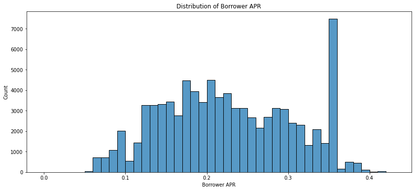

```python
# start with a standard-scaled plot
binsize = 0.01
bins = np.arange(0, loan_data_new['borrower_apr'].max()+binsize, binsize)

plt.figure(figsize=[14, 6])
sb.histplot(x='borrower_apr', data=loan_data_new, bins=bins)
plt.xlabel('Borrower APR')
plt.title('Distribution of Borrower APR');
plt.show()
```

The distribution of APR looks multimodal. A small peak centered at 0.09, a large peak centered at 0.18. There is also a small peak centered 0.29. Additionally, there is a very sharp peak between 0.35 and 0.36. Only very few loans have APR greater than 0.41.

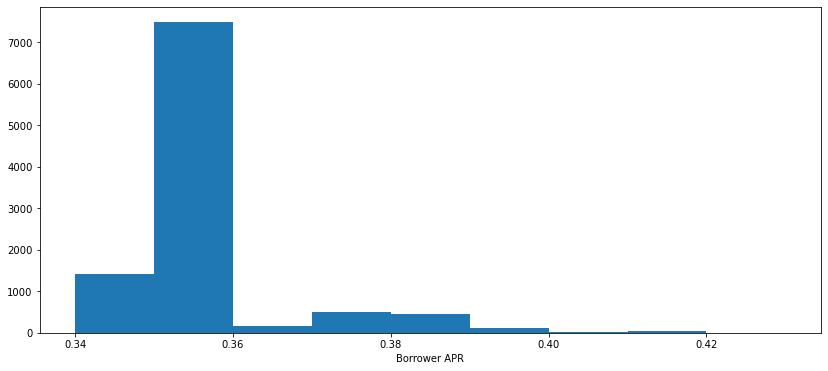

```python
# there's a long tail in the distribution, so let's put it on a log scale instead
log_binsize = 0.01
bins = np.arange(0.34, loan_data_new['borrower_apr'].max()+binsize, binsize)
# bins = 1

plt.figure(figsize=[14, 6])
plt.hist(x='borrower_apr', data=loan_data_new, bins=bins)
# plt.xscale('log')
# plt.xticks([0.34, 0.35, 0.36, 0.37, 0.38, 0.39])
plt.xlabel('Borrower APR')
plt.show()
```

```python
# Check loans with APR greater than 0.41
loan_data_new[loan_data_new.borrower_apr>0.41]
```

|  | listing_key | term | loan_status | borrower_apr | borrower_rate | lender_yield | estimated_effective_yield | estimated_loss | estimated_return | prosper_rating_alpha | prosper_score | is_borrower_home_owner | currently_in_group | credit_score_range_lower | credit_score_range_upper |
| --- | --- | --- | --- | --- | --- | --- | --- | --- | --- | --- | --- | --- | --- | --- | --- |
| 8750 | 6F2934946298365730F50B9 | 36 | Completed | 0.41355 | 0.35 | 0.34 | 0.1369 | 0.183 | 0.1369 | HR | 4.0 | True | False | 640.0 | 659.0 |
| 9643 | A6D43496056198742B7E7AD | 36 | Completed | 0.41355 | 0.35 | 0.34 | 0.1369 | 0.183 | 0.1369 | HR | 4.0 | True | False | 680.0 | 699.0 |
| 11003 | CD423499571995073818889 | 36 | Chargedoff | 0.41355 | 0.35 | 0.34 | 0.1369 | 0.183 | 0.1369 | HR | 4.0 | False | False | 660.0 | 679.0 |
| 11658 | F53D3494261198684DEC21B | 36 | Completed | 0.41355 | 0.35 | 0.34 | 0.1369 | 0.183 | 0.1369 | HR | 5.0 | False | False | 640.0 | 659.0 |
| 12277 | 053B34913054260157B2C53 | 36 | Completed | 0.41355 | 0.35 | 0.34 | 0.1369 | 0.183 | 0.1369 | HR | 5.0 | False | False | 640.0 | 659.0 |
| 15624 | 9A4E3492821389543047631 | 36 | Completed | 0.41355 | 0.35 | 0.34 | -0.0461 | 0.366 | -0.0461 | HR | 1.0 | False | False | 660.0 | 679.0 |
| 17224 | CF983502168332613E687C6 | 36 | Completed | 0.41355 | 0.35 | 0.34 | 0.3199 | 0.240 | 0.0799 | HR | 2.0 | False | True | 660.0 | 679.0 |
| 18473 | 37A735019031281873636AA | 36 | Completed | 0.41355 | 0.35 | 0.34 | 0.0799 | 0.240 | 0.0799 | HR | 2.0 | True | False | 660.0 | 679.0 |
| 19089 | BAC4350200668046339B539 | 36 | Completed | 0.41355 | 0.35 | 0.34 | -0.0461 | 0.366 | -0.0461 | HR | 1.0 | True | False | 700.0 | 719.0 |
| 19488 | 7E213498168265169DF9A72 | 36 | Completed | 0.41355 | 0.35 | 0.34 | 0.1369 | 0.183 | 0.1369 | HR | 4.0 | True | False | 640.0 | 659.0 |
| 20169 | 43183492371043609C0DBA0 | 36 | Completed | 0.41355 | 0.35 | 0.34 | -0.0461 | 0.366 | -0.0461 | HR | 1.0 | False | True | 640.0 | 659.0 |
| 20467 | 18633502790520131475079 | 36 | Completed | 0.41355 | 0.35 | 0.34 | 0.1369 | 0.183 | 0.1369 | HR | 4.0 | False | False | 640.0 | 659.0 |
| 21804 | 174F34991712174171DAE23 | 36 | Chargedoff | 0.41355 | 0.35 | 0.34 | 0.1369 | 0.183 | 0.1369 | HR | 4.0 | False | False | 640.0 | 659.0 |
| 28838 | 5A4635022387065130F5FEC | 36 | Completed | 0.41355 | 0.35 | 0.34 | 0.3199 | 0.183 | 0.1369 | HR | 5.0 | False | False | 620.0 | 639.0 |
| 29814 | 64AB348742935762020E30F | 36 | Completed | 0.41355 | 0.35 | 0.34 | 0.1369 | 0.183 | 0.1369 | HR | 4.0 | False | False | 640.0 | 659.0 |
| 31674 | C28B3497770334814890845 | 36 | Chargedoff | 0.41355 | 0.35 | 0.34 | 0.1369 | 0.183 | 0.1369 | HR | 4.0 | True | False | 660.0 | 679.0 |
| 31732 | 818935005254886538814B7 | 36 | Completed | 0.41355 | 0.35 | 0.34 | -0.0461 | 0.366 | -0.0461 | HR | 1.0 | False | False | 600.0 | 619.0 |
| 34027 | D93134927722472926C9FA3 | 36 | Chargedoff | 0.41355 | 0.35 | 0.34 | -0.0461 | 0.366 | -0.0461 | HR | 1.0 | True | False | 620.0 | 639.0 |
| 35632 | 04063498878846442343A64 | 36 | Defaulted | 0.41355 | 0.35 | 0.34 | 0.0799 | 0.240 | 0.0799 | HR | 3.0 | False | False | 640.0 | 659.0 |
| 36015 | 84223502203384887183BB3 | 36 | Completed | 0.41355 | 0.35 | 0.34 | 0.1369 | 0.183 | 0.1369 | HR | 5.0 | True | True | 640.0 | 659.0 |
| 39844 | 3D9F3483288805496169BDF | 36 | Chargedoff | 0.41355 | 0.35 | 0.34 | 0.1369 | 0.183 | 0.1369 | HR | 4.0 | False | False | 700.0 | 719.0 |
| 43560 | EA42349558645294551F1DD | 36 | Chargedoff | 0.41355 | 0.35 | 0.34 | 0.1369 | 0.183 | 0.1369 | HR | 5.0 | False | False | 640.0 | 659.0 |
| 47754 | 52923494494924817037E6D | 36 | Completed | 0.41355 | 0.35 | 0.34 | 0.1369 | 0.183 | 0.1369 | HR | 4.0 | False | False | 640.0 | 659.0 |
| 48568 | 1C1F34990777267665BB7D8 | 36 | Completed | 0.41355 | 0.35 | 0.34 | 0.1369 | 0.183 | 0.1369 | HR | 4.0 | True | False | 640.0 | 659.0 |
| 53860 | 75003495320418943B95905 | 36 | Chargedoff | 0.41355 | 0.35 | 0.34 | 0.1369 | 0.183 | 0.1369 | HR | 4.0 | False | False | 680.0 | 699.0 |
| 56449 | 855B3500370790276F76570 | 36 | Chargedoff | 0.41355 | 0.35 | 0.34 | 0.0799 | 0.240 | 0.0799 | HR | 3.0 | True | False | 640.0 | 659.0 |
| 58811 | 778D35023134008076787AC | 36 | Completed | 0.41355 | 0.35 | 0.34 | 0.1369 | 0.183 | 0.1369 | HR | 4.0 | True | False | 640.0 | 659.0 |
| 60501 | CB9934985697674700872F0 | 36 | Completed | 0.41355 | 0.35 | 0.34 | 0.1369 | 0.183 | 0.1369 | HR | 4.0 | True | False | 640.0 | 659.0 |
| 60791 | DCFC3491361536898F39DEF | 36 | Chargedoff | 0.41355 | 0.35 | 0.34 | 0.1369 | 0.183 | 0.1369 | HR | 5.0 | True | False | 640.0 | 659.0 |
| 61208 | 5DBD3502596157154E8AE18 | 36 | Completed | 0.41355 | 0.35 | 0.34 | 0.3199 | 0.183 | 0.1369 | HR | 4.0 | False | False | 640.0 | 659.0 |
| 69105 | 07403492519035412ABFFAC | 36 | Completed | 0.41355 | 0.35 | 0.34 | 0.1369 | 0.183 | 0.1369 | HR | 4.0 | False | False | 680.0 | 699.0 |
| 78712 | CB47349126596782913C9B6 | 36 | Chargedoff | 0.41355 | 0.35 | 0.34 | 0.1369 | 0.183 | 0.1369 | HR | 4.0 | True | False | 660.0 | 679.0 |
| 84502 | 61403494169635511941B24 | 36 | Completed | 0.41355 | 0.35 | 0.34 | 0.0799 | 0.240 | 0.0799 | HR | 3.0 | False | False | 640.0 | 659.0 |
| 88478 | BE0D3495098151875F88072 | 36 | Completed | 0.41355 | 0.35 | 0.34 | -0.0461 | 0.366 | -0.0461 | HR | 1.0 | True | False | 620.0 | 639.0 |
| 90311 | E42035017336385780DCEFD | 36 | Completed | 0.41355 | 0.35 | 0.34 | 0.3199 | 0.183 | 0.1369 | HR | 4.0 | False | False | 640.0 | 659.0 |
| 91546 | 68EC35025821928350D9DA9 | 36 | Completed | 0.41355 | 0.35 | 0.34 | 0.3199 | 0.240 | 0.0799 | HR | 3.0 | True | False | 640.0 | 659.0 |
| 94193 | F050350029684090105C131 | 36 | Completed | 0.41355 | 0.35 | 0.34 | 0.0799 | 0.240 | 0.0799 | HR | 3.0 | False | False | 640.0 | 659.0 |
| 97997 | B6DA34917887583454AA18B | 36 | Defaulted | 0.41355 | 0.35 | 0.34 | 0.1369 | 0.183 | 0.1369 | HR | 4.0 | True | False | 660.0 | 679.0 |
| 101039 | BB32349805543897000B66B | 36 | Chargedoff | 0.41355 | 0.35 | 0.34 | 0.1369 | 0.183 | 0.1369 | HR | 5.0 | True | False | 600.0 | 619.0 |
| 101320 | 6DE33500652584591F7CBA2 | 36 | Completed | 0.41355 | 0.35 | 0.34 | 0.0799 | 0.240 | 0.0799 | HR | 2.0 | True | False | 660.0 | 679.0 |
| 104578 | CF033493585950336648CBD | 36 | Completed | 0.41355 | 0.35 | 0.34 | 0.1369 | 0.183 | 0.1369 | HR | 4.0 | False | False | 640.0 | 659.0 |
| 105045 | 7F7C34899369950965DF4C6 | 36 | Completed | 0.41355 | 0.35 | 0.34 | 0.0799 | 0.240 | 0.0799 | HR | 3.0 | True | False | 700.0 | 719.0 |
| 105889 | CC0C3497369291932E3CF0E | 36 | Chargedoff | 0.42395 | 0.36 | 0.34 | 0.1369 | 0.183 | 0.1369 | HR | 4.0 | False | False | 720.0 | 739.0 |
| 111333 | 90F035015592764708866F8 | 36 | Completed | 0.41355 | 0.35 | 0.34 | 0.1369 | 0.183 | 0.1369 | HR | 4.0 | False | False | 700.0 | 719.0 |
| 111463 | 912F34914006342267F07BF | 36 | Completed | 0.41355 | 0.35 | 0.34 | 0.1369 | 0.183 | 0.1369 | HR | 4.0 | False | False | 620.0 | 639.0 |

We look at the distribution of the next variable of interest which is loan Status

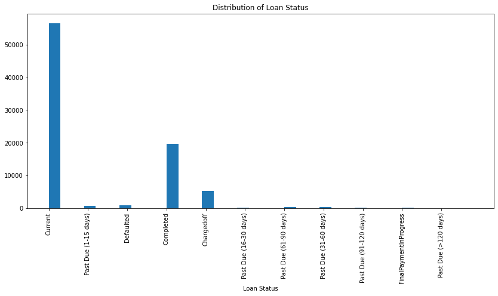

```python
status = len(loan_data_new['loan_status'].unique())
bins = np.arange(0, status, 0.3)
plt.figure(figsize=[14, 6])
plt.hist(data = loan_data_new, x = 'loan_status', bins=bins);
plt.xlabel('Loan Status');
plt.title('Distribution of Loan Status')
plt.xticks(rotation=90);
```

The highest loan status is Current, followed by Completed then Chargedoff

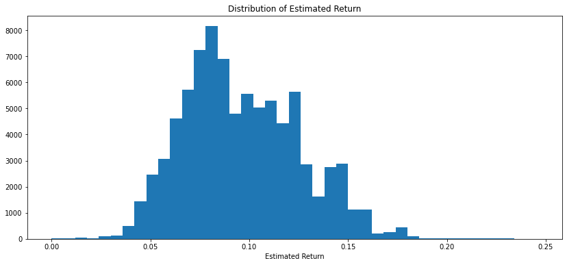

```python
bins = np.arange(0, 0.25, 0.006)
plt.figure(figsize=[14, 6])
plt.hist(data = loan_data_new, x = 'estimated_return', bins=bins);
plt.xlabel('Estimated Return');
plt.title('Distribution of Estimated Return')
```

Then we consider the distribution of loan terms, Prosper Rating

```python
# Convert ProsperRating into ordered categorical types
rate_order = ['HR','E','D','C','B','A','AA']
ordered_rate = pd.api.types.CategoricalDtype(ordered = True,
                                    categories = rate_order)
loan_data_new['prosper_rating_alpha'] = loan_data_new['prosper_rating_alpha'].astype(ordered_rate)
```

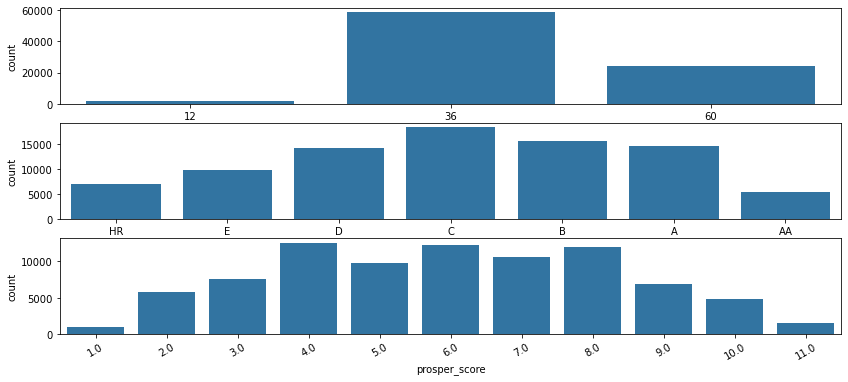

```python
fig, ax = plt.subplots(nrows=3, figsize = [14, 6])
default_color = sb.color_palette()[0]
sb.countplot(data = loan_data_new, x = 'term', color = default_color, ax = ax[0])
sb.countplot(data = loan_data_new, x = 'prosper_rating_alpha', color = default_color, ax = ax[1])
sb.countplot(data = loan_data_new, x = 'prosper_score', color = default_color, ax = ax[2]);
plt.xticks(rotation=30);
```

The months with the highest loan term is 36months, followed by 60 months while the least is 12 months.

The ratings of most of the borrowers are among C to A.

### Of the features you investigated, were there any unusual distributions? Did you perform any operations on the data to tidy, adjust, or change the form of the data? If so, why did you do this?

> There were no unusual distributions, and there was no need to tidy, adjust or change the form of the data.

## Bivariate Exploration

> To start off with, I want to look at the pairwise correlations present between features in the data.

```python
numeric_vars = ['borrower_apr','borrower_rate','estimated_effective_yield', 'estimated_return','estimated_loss']
categoric_vars = ['term', 'prosper_score','prosper_rating_alpha']
```

```
loan_data_new.shape= (84853, 15)
loan_data_samp.shape= (500, 15)
```

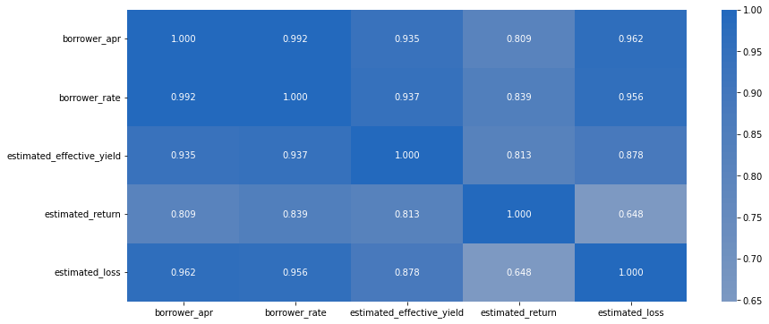

```python
# plot matrix: sample 500 loans so that plots are clearer and they render faster
print("loan_data_new.shape=",loan_data_new.shape)
loan_data_samp = loan_data_new.sample(n=500, replace = False)
print("loan_data_samp.shape=",loan_data_samp.shape)

# correlation plot
plt.figure(figsize =[14, 6])
sb.heatmap(loan_data_samp[numeric_vars].corr(), annot = True, fmt = '.3f',
           cmap = 'vlag_r', center = 0);
```

The Correlation between the Borrower APR and the other features such as Borrower Rate, Estimated Effective Yield, Estimated Return and Estimated Loss are all positively correlated.

This means that an increase in the Borrower APR will lead to an increase in all these features.

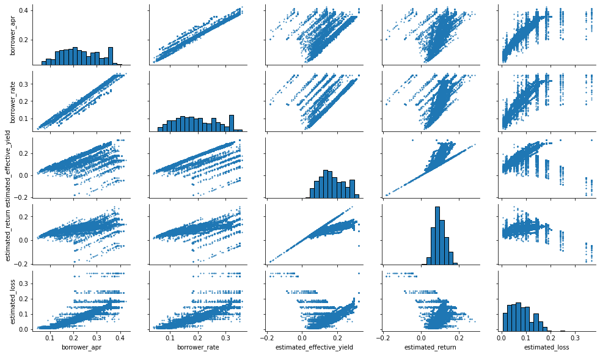

```python
g = sb.PairGrid(data = loan_data, vars = numeric_vars);
g = g.map_diag(plt.hist, bins=20, edgecolor='black');
g.map_offdiag(plt.scatter, s=1);

## set Plot Dimensions - FIGURE LEVEL
g.fig.set_size_inches(14,8);
plt.show();
```

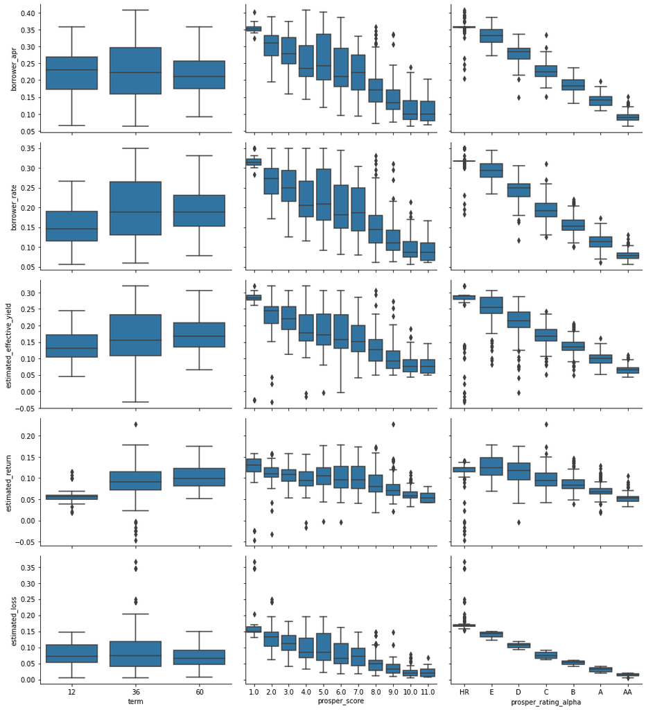

```python
loan_data_samp = loan_data_new.sample(n=2000, replace = False)


def boxgrid(x, y, **kwargs):
    """ Quick hack for creating box plots with seaborn's PairGrid. """
    default_color = sb.color_palette()[0]
    sb.boxplot(x=x, y=y, color=default_color)

# plt.figure(figsize = [14, 6])
g.fig.set_size_inches(14,8);
g = sb.PairGrid(data = loan_data_samp, y_vars = numeric_vars,
                                        x_vars = categoric_vars,
                height = 3, aspect = 1.5)
g.map(boxgrid)
plt.show();
```

The figure shows that the borrower APR decreases with the better rating. Borrowers with the best Prosper ratings have the lowest APR. It means that the Prosper rating has a strong effect on borrower APR. Borrowers with better prosper rating also have lower estimated losses, estimated effective yields and lower borrower rate.

Finally, let's look at relationships between the categorical features

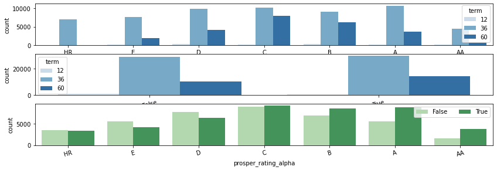

```python
plt.figure(figsize = [14, 6])

# subplot 1: Prosper rating vs term
plt.subplot(4, 1, 1)
sb.countplot(data = loan_data_new, x = 'prosper_rating_alpha', hue = 'term', palette = 'Blues')

# subplot 2: is_borrower_home_owner vs. term
ax = plt.subplot(4, 1, 2)
sb.countplot(data = loan_data_new, x = 'is_borrower_home_owner', hue = 'term', palette = 'Blues')
plt.xticks(rotation = 15)


# subplot 3: Prosper rating vs. employment status, use different color palette
ax = plt.subplot(4, 1, 3)
sb.countplot(data = loan_data_new, x = 'prosper_rating_alpha', hue = 'is_borrower_home_owner', palette = 'Greens')
ax.legend(loc = 1, ncol = 2); # re-arrange legend to remove overlapping
plt.xticks(rotation = 15);
```

Most borrowers chose to go for loans with term of 36, while less borrowers chose the 60 term loans while very few borrowers chose the 12months term loan

### How did the feature(s) of interest vary with other features in the dataset?

> The Prosper rating has a strong effect on the borrower APR, which decreases with the better rating. At higher Prosper Rating, there were more home owners than non home onwers, while at lower Prosper Rating, there were more non home owners than home owners.

### Did you observe any interesting relationships between the other features (not the main feature(s) of interest)?

> There is a relationship between prosper rating and term. There are more 60 month loans on B and C ratings. There is only 36 months loans for HR rating borrowers.

## Multivariate Exploration

> The main thing I want to explore in this section of the analysis is how the categorical variables (Loan Terms and Prosper rating) play into the relationship between borrower APR and Rate.

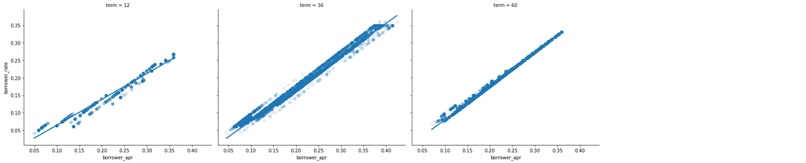

```python
# Term effect on relationship of Borrower APR and Rate
g=sb.FacetGrid(data=loan_data_new, aspect=1.2, height=5, col='term', col_wrap=4)
g.map(sb.regplot, 'borrower_apr', 'borrower_rate', scatter_kws={'alpha':0.1});
g.add_legend();
```

Term doesn't seem to have effect on relationship of Borrower APR and Rate

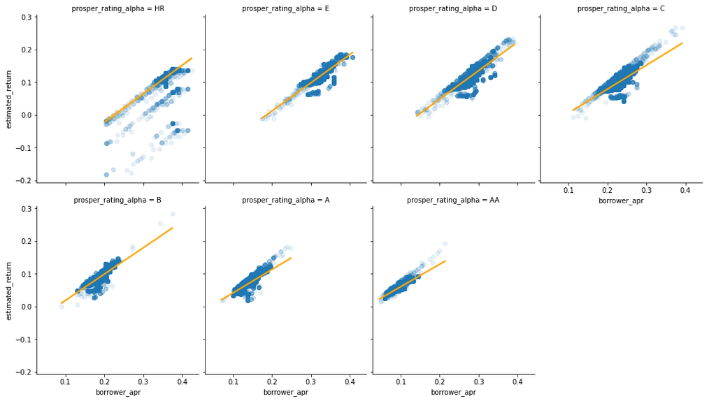

```python
# Prosper rating effect on relationship of Borrower APR and Estimated Return
g=sb.FacetGrid(data=loan_data_new, aspect=1.2, height=5, col='prosper_rating_alpha', col_wrap=4)
g.map(sb.regplot, 'borrower_apr', 'estimated_return', scatter_kws={'alpha':0.1}, line_kws={'color':'orange'});
# Set the plot Dimensions -Figure Level
g.fig.set_size_inches(14,8);
g.add_legend();
```

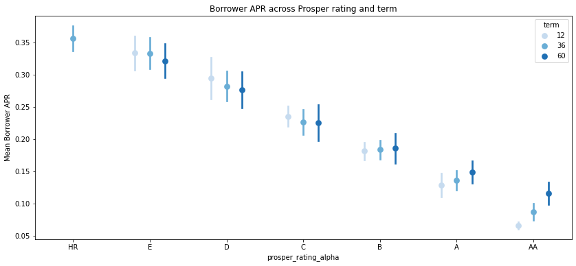

```python
fig = plt.figure(figsize = [14, 6])
ax = sb.pointplot(data = loan_data_new, x = 'prosper_rating_alpha', y = 'borrower_apr', hue = 'term',
           palette = 'Blues', linestyles = '', dodge = 0.4, ci='sd')
plt.title('Borrower APR across Prosper rating and term')
plt.ylabel('Mean Borrower APR')
ax.set_yticklabels([],minor = True);
```

Interestingly, the borrower APR decrease with the increase of borrow term for people with HR-C raings. But for people with B-AA ratings, the APR increase with the increase of borrow term.

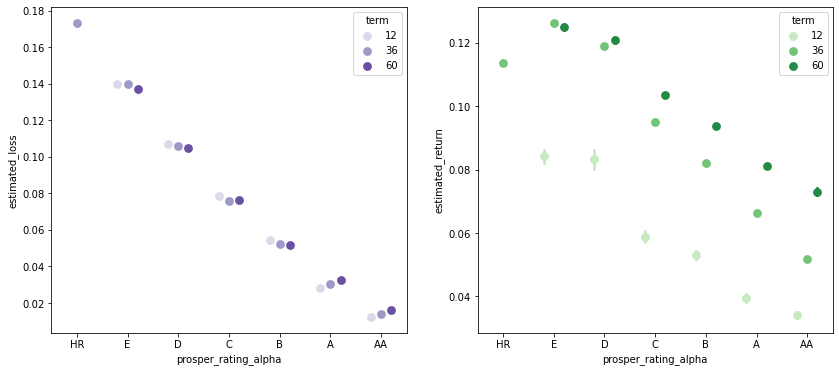

```python
fig, ax = plt.subplots(ncols=2, figsize=[14, 6])
sb.pointplot(data = loan_data_new, x = 'prosper_rating_alpha', y = 'estimated_loss', hue = 'term',
           palette = 'Purples', linestyles = '', dodge = 0.4, ax=ax[0])
sb.pointplot(data = loan_data_new, x = 'prosper_rating_alpha', y = 'estimated_return', hue = 'term',
           palette = 'Greens', linestyles = '', dodge = 0.4, ax=ax[1]);
```

There is a relationship between the estimated loss and the prosper rating alpha, in which the estimated loss seems to decrease with better prosper rating. While there is no relationship between term and prosper rating alpha for the estimated loss.

### Were there any interesting or surprising interactions between features?

> A surprising interaction is that the borrower APR decreases with the better prosper rating. Borrowers with the best Prosper ratings have the lowest APR. It means that the Prosper rating has a strong effect on borrower APR. Borrowers with better prosper rating also have lower estimated losses, estimated effective yields and lower borrower rate.

```python
# export the cleaned dataset for exploratory data analysis
loan_data_new.to_csv('loan_data_new_cleaned.csv')
```